# Risk Factor Analysis

## Outcome Variable

**Outcome Variable:** y_rate_wtkg

## Predictor Variables

**Intervention Variable:** nhh

**Adjustment Set:**

- arm
- W_mage
- meducyrs
- feducyrs
- W_mhtcm
- W_mwtkg
- W_mbmi
- W_nrooms
- trth2o
- cleanck
- impfloor
- impsan
- safeh20
- delta_W_mage
- delta_meducyrs
- delta_feducyrs
- delta_W_mhtcm
- delta_W_mwtkg
- delta_W_mbmi
- delta_W_nrooms
- delta_trth2o
- delta_cleanck
- delta_impfloor
- delta_impsan
- delta_safeh20

## Stratifying Variables

The analysis was stratified on these variable(s):

- agecat
- studyid
- country

## Data Summary

| agecat | studyid | country | nhh | n_cell | n | outcome_variable |
| --- | --- | --- | --- | --- | --- | --- |
| 0-3 months | ki1000108-IRC | INDIA | 3 or less | 57 | 394 | y_rate_wtkg |
| 0-3 months | ki1000108-IRC | INDIA | 4-5 | 151 | 394 | y_rate_wtkg |
| 0-3 months | ki1000108-IRC | INDIA | 6-7 | 101 | 394 | y_rate_wtkg |
| 0-3 months | ki1000108-IRC | INDIA | 8+ | 85 | 394 | y_rate_wtkg |
| 0-3 months | ki1017093-NIH-Birth | BANGLADESH | 3 or less | 101 | 565 | y_rate_wtkg |
| 0-3 months | ki1017093-NIH-Birth | BANGLADESH | 4-5 | 238 | 565 | y_rate_wtkg |
| 0-3 months | ki1017093-NIH-Birth | BANGLADESH | 6-7 | 132 | 565 | y_rate_wtkg |
| 0-3 months | ki1017093-NIH-Birth | BANGLADESH | 8+ | 94 | 565 | y_rate_wtkg |
| 0-3 months | ki1017093b-PROVIDE | BANGLADESH | 3 or less | 123 | 640 | y_rate_wtkg |
| 0-3 months | ki1017093b-PROVIDE | BANGLADESH | 4-5 | 296 | 640 | y_rate_wtkg |
| 0-3 months | ki1017093b-PROVIDE | BANGLADESH | 6-7 | 136 | 640 | y_rate_wtkg |
| 0-3 months | ki1017093b-PROVIDE | BANGLADESH | 8+ | 85 | 640 | y_rate_wtkg |
| 0-3 months | ki1017093c-NIH-Crypto | BANGLADESH | 3 or less | 110 | 725 | y_rate_wtkg |
| 0-3 months | ki1017093c-NIH-Crypto | BANGLADESH | 4-5 | 324 | 725 | y_rate_wtkg |
| 0-3 months | ki1017093c-NIH-Crypto | BANGLADESH | 6-7 | 171 | 725 | y_rate_wtkg |
| 0-3 months | ki1017093c-NIH-Crypto | BANGLADESH | 8+ | 120 | 725 | y_rate_wtkg |
| 3-6 months | ki1000108-IRC | INDIA | 3 or less | 57 | 399 | y_rate_wtkg |
| 3-6 months | ki1000108-IRC | INDIA | 4-5 | 153 | 399 | y_rate_wtkg |
| 3-6 months | ki1000108-IRC | INDIA | 6-7 | 104 | 399 | y_rate_wtkg |
| 3-6 months | ki1000108-IRC | INDIA | 8+ | 85 | 399 | y_rate_wtkg |
| 3-6 months | ki1017093-NIH-Birth | BANGLADESH | 3 or less | 89 | 522 | y_rate_wtkg |
| 3-6 months | ki1017093-NIH-Birth | BANGLADESH | 4-5 | 223 | 522 | y_rate_wtkg |
| 3-6 months | ki1017093-NIH-Birth | BANGLADESH | 6-7 | 125 | 522 | y_rate_wtkg |
| 3-6 months | ki1017093-NIH-Birth | BANGLADESH | 8+ | 85 | 522 | y_rate_wtkg |
| 3-6 months | ki1017093b-PROVIDE | BANGLADESH | 3 or less | 105 | 601 | y_rate_wtkg |
| 3-6 months | ki1017093b-PROVIDE | BANGLADESH | 4-5 | 287 | 601 | y_rate_wtkg |
| 3-6 months | ki1017093b-PROVIDE | BANGLADESH | 6-7 | 130 | 601 | y_rate_wtkg |
| 3-6 months | ki1017093b-PROVIDE | BANGLADESH | 8+ | 79 | 601 | y_rate_wtkg |
| 3-6 months | ki1017093c-NIH-Crypto | BANGLADESH | 3 or less | 103 | 702 | y_rate_wtkg |
| 3-6 months | ki1017093c-NIH-Crypto | BANGLADESH | 4-5 | 317 | 702 | y_rate_wtkg |

[output cut: 138 more lines]

The following strata were considered:

- agecat: 0-3 months, studyid: ki1000108-IRC, country: INDIA
- agecat: 0-3 months, studyid: ki1017093-NIH-Birth, country: BANGLADESH
- agecat: 0-3 months, studyid: ki1017093b-PROVIDE, country: BANGLADESH
- agecat: 0-3 months, studyid: ki1017093c-NIH-Crypto, country: BANGLADESH
- agecat: 12-15 months, studyid: ki1000108-IRC, country: INDIA
- agecat: 12-15 months, studyid: ki1000304b-SAS-FoodSuppl, country: INDIA
- agecat: 12-15 months, studyid: ki1017093-NIH-Birth, country: BANGLADESH
- agecat: 12-15 months, studyid: ki1017093b-PROVIDE, country: BANGLADESH
- agecat: 12-15 months, studyid: ki1017093c-NIH-Crypto, country: BANGLADESH
- agecat: 12-15 months, studyid: ki1148112-LCNI-5, country: MALAWI
- agecat: 15-18 months, studyid: ki1000108-IRC, country: INDIA
- agecat: 15-18 months, studyid: ki1000304b-SAS-FoodSuppl, country: INDIA
- agecat: 15-18 months, studyid: ki1017093-NIH-Birth, country: BANGLADESH
- agecat: 15-18 months, studyid: ki1017093b-PROVIDE, country: BANGLADESH
- agecat: 15-18 months, studyid: ki1017093c-NIH-Crypto, country: BANGLADESH
- agecat: 15-18 months, studyid: ki1148112-LCNI-5, country: MALAWI
- agecat: 18-21 months, studyid: ki1000108-IRC, country: INDIA
- agecat: 18-21 months, studyid: ki1017093-NIH-Birth, country: BANGLADESH
- agecat: 18-21 months, studyid: ki1017093b-PROVIDE, country: BANGLADESH
- agecat: 18-21 months, studyid: ki1017093c-NIH-Crypto, country: BANGLADESH
- agecat: 18-21 months, studyid: ki1148112-LCNI-5, country: MALAWI
- agecat: 21-24 months, studyid: ki1000108-IRC, country: INDIA
- agecat: 21-24 months, studyid: ki1017093-NIH-Birth, country: BANGLADESH
- agecat: 21-24 months, studyid: ki1017093b-PROVIDE, country: BANGLADESH
- agecat: 21-24 months, studyid: ki1017093c-NIH-Crypto, country: BANGLADESH
- agecat: 21-24 months, studyid: ki1148112-LCNI-5, country: MALAWI
- agecat: 3-6 months, studyid: ki1000108-IRC, country: INDIA
- agecat: 3-6 months, studyid: ki1017093-NIH-Birth, country: BANGLADESH
- agecat: 3-6 months, studyid: ki1017093b-PROVIDE, country: BANGLADESH
- agecat: 3-6 months, studyid: ki1017093c-NIH-Crypto, country: BANGLADESH
- agecat: 6-9 months, studyid: ki1000108-IRC, country: INDIA
- agecat: 6-9 months, studyid: ki1000304b-SAS-FoodSuppl, country: INDIA
- agecat: 6-9 months, studyid: ki1017093-NIH-Birth, country: BANGLADESH
- agecat: 6-9 months, studyid: ki1017093b-PROVIDE, country: BANGLADESH
- agecat: 6-9 months, studyid: ki1017093c-NIH-Crypto, country: BANGLADESH
- agecat: 6-9 months, studyid: ki1148112-LCNI-5, country: MALAWI
- agecat: 9-12 months, studyid: ki1000108-IRC, country: INDIA
- agecat: 9-12 months, studyid: ki1000304b-SAS-FoodSuppl, country: INDIA
- agecat: 9-12 months, studyid: ki1017093-NIH-Birth, country: BANGLADESH
- agecat: 9-12 months, studyid: ki1017093b-PROVIDE, country: BANGLADESH
- agecat: 9-12 months, studyid: ki1017093c-NIH-Crypto, country: BANGLADESH
- agecat: 9-12 months, studyid: ki1148112-LCNI-5, country: MALAWI

## Methods Detail

We’re interested in the causal parameters $E[Y_a]$ for all values of $a \in \mathcal{A}$. These parameters represent the mean outcome if, possibly contrary to fact, we intervened to set all units to have $A=a$. Under the randomization and positivity assumptions, these are identified by the statistical parameters $\psi_a=E_W[E_{Y|A,W}(Y|A=a,W)]$. In addition, we’re interested in the mean of $Y$, $E[Y]$ under no intervention (the observed mean). We will estimate these parameters by using SuperLearner to fit the relevant likelihood factors – $E_{Y|A,W}(Y|A=a,W)$ and $p(A=a|W)$, and then updating our likelihood fit using a joint TMLE.

For unadjusted analyses ($W=\{\}$), initial likelihoods were estimated using Lrnr_glm to estimate the simple $E(Y|A)$ and Lrnr_mean to estimate $p(A)$. For adjusted analyses, a small library containing Lrnr_glmnet, Lrnr_xgboost, and Lrnr_mean was used.

Having estimated these parameters, we will then use the delta method to estimate relative risks and attributable risks relative to a prespecified baseline level of $A$.

# Results Detail

## Results Plots

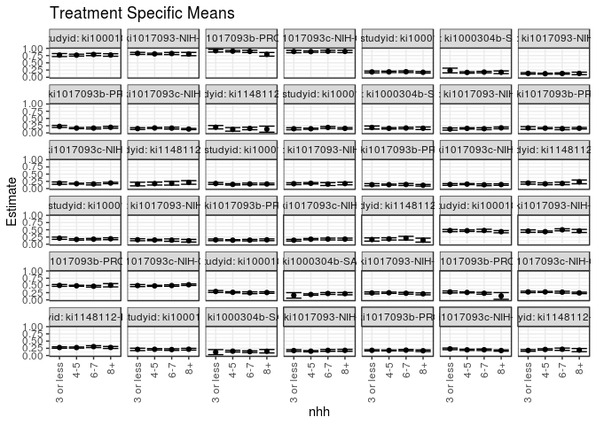

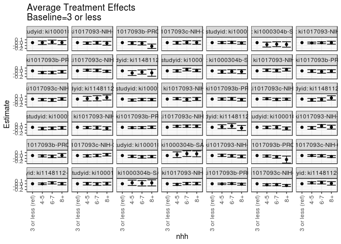

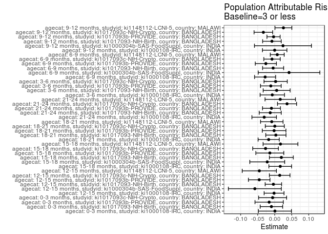

## Results Table

### Parameter: TSM

| agecat | studyid | country | intervention_level | baseline_level | estimate | ci_lower | ci_upper |
| --- | --- | --- | --- | --- | --- | --- | --- |
| 0-3 months | ki1000108-IRC | INDIA | 3 or less | NA | 0.7672860 | 0.7149858 | 0.8195862 |
| 0-3 months | ki1000108-IRC | INDIA | 4-5 | NA | 0.7653314 | 0.7315382 | 0.7991247 |
| 0-3 months | ki1000108-IRC | INDIA | 6-7 | NA | 0.7882524 | 0.7495033 | 0.8270015 |
| 0-3 months | ki1000108-IRC | INDIA | 8+ | NA | 0.7699875 | 0.7253798 | 0.8145953 |
| 0-3 months | ki1017093-NIH-Birth | BANGLADESH | 3 or less | NA | 0.8259420 | 0.7908996 | 0.8609844 |
| 0-3 months | ki1017093-NIH-Birth | BANGLADESH | 4-5 | NA | 0.8085188 | 0.7844913 | 0.8325463 |
| 0-3 months | ki1017093-NIH-Birth | BANGLADESH | 6-7 | NA | 0.8214972 | 0.7850402 | 0.8579542 |
| 0-3 months | ki1017093-NIH-Birth | BANGLADESH | 8+ | NA | 0.8034891 | 0.7473362 | 0.8596421 |
| 0-3 months | ki1017093b-PROVIDE | BANGLADESH | 3 or less | NA | 0.9179017 | 0.8735144 | 0.9622891 |
| 0-3 months | ki1017093b-PROVIDE | BANGLADESH | 4-5 | NA | 0.9034626 | 0.8776520 | 0.9292733 |
| 0-3 months | ki1017093b-PROVIDE | BANGLADESH | 6-7 | NA | 0.8949693 | 0.8566283 | 0.9333104 |
| 0-3 months | ki1017093b-PROVIDE | BANGLADESH | 8+ | NA | 0.7924074 | 0.7290609 | 0.8557539 |
| 0-3 months | ki1017093c-NIH-Crypto | BANGLADESH | 3 or less | NA | 0.8905977 | 0.8479231 | 0.9332724 |
| 0-3 months | ki1017093c-NIH-Crypto | BANGLADESH | 4-5 | NA | 0.8861731 | 0.8611403 | 0.9112058 |
| 0-3 months | ki1017093c-NIH-Crypto | BANGLADESH | 6-7 | NA | 0.8993486 | 0.8641605 | 0.9345367 |
| 0-3 months | ki1017093c-NIH-Crypto | BANGLADESH | 8+ | NA | 0.8935241 | 0.8527888 | 0.9342593 |
| 3-6 months | ki1000108-IRC | INDIA | 3 or less | NA | 0.4731149 | 0.4360224 | 0.5102074 |
| 3-6 months | ki1000108-IRC | INDIA | 4-5 | NA | 0.4686796 | 0.4421549 | 0.4952043 |
| 3-6 months | ki1000108-IRC | INDIA | 6-7 | NA | 0.4760902 | 0.4339464 | 0.5182340 |
| 3-6 months | ki1000108-IRC | INDIA | 8+ | NA | 0.4340083 | 0.3956280 | 0.4723886 |
| 3-6 months | ki1017093-NIH-Birth | BANGLADESH | 3 or less | NA | 0.4535722 | 0.4113065 | 0.4958378 |
| 3-6 months | ki1017093-NIH-Birth | BANGLADESH | 4-5 | NA | 0.4345374 | 0.4108417 | 0.4582331 |
| 3-6 months | ki1017093-NIH-Birth | BANGLADESH | 6-7 | NA | 0.4990669 | 0.4640989 | 0.5340349 |
| 3-6 months | ki1017093-NIH-Birth | BANGLADESH | 8+ | NA | 0.4601111 | 0.4076299 | 0.5125922 |
| 3-6 months | ki1017093b-PROVIDE | BANGLADESH | 3 or less | NA | 0.5004471 | 0.4676284 | 0.5332658 |
| 3-6 months | ki1017093b-PROVIDE | BANGLADESH | 4-5 | NA | 0.4874861 | 0.4696259 | 0.5053464 |
| 3-6 months | ki1017093b-PROVIDE | BANGLADESH | 6-7 | NA | 0.4714118 | 0.4437134 | 0.4991102 |
| 3-6 months | ki1017093b-PROVIDE | BANGLADESH | 8+ | NA | 0.5057436 | 0.4492251 | 0.5622621 |
| 3-6 months | ki1017093c-NIH-Crypto | BANGLADESH | 3 or less | NA | 0.4953076 | 0.4596567 | 0.5309585 |
| 3-6 months | ki1017093c-NIH-Crypto | BANGLADESH | 4-5 | NA | 0.4851499 | 0.4669226 | 0.5033772 |

[output cut: 138 more lines]

### Parameter: E(Y)

| agecat | studyid | country | intervention_level | baseline_level | estimate | ci_lower | ci_upper |
| --- | --- | --- | --- | --- | --- | --- | --- |
| 0-3 months | ki1000108-IRC | INDIA | NA | NA | 0.7679906 | 0.7485485 | 0.7874326 |
| 0-3 months | ki1017093-NIH-Birth | BANGLADESH | NA | NA | 0.8163500 | 0.7995330 | 0.8331670 |
| 0-3 months | ki1017093b-PROVIDE | BANGLADESH | NA | NA | 0.9016472 | 0.8868914 | 0.9164029 |
| 0-3 months | ki1017093c-NIH-Crypto | BANGLADESH | NA | NA | 0.8845220 | 0.8699746 | 0.8990694 |
| 3-6 months | ki1000108-IRC | INDIA | NA | NA | 0.4660717 | 0.4485044 | 0.4836390 |
| 3-6 months | ki1017093-NIH-Birth | BANGLADESH | NA | NA | 0.4593975 | 0.4422221 | 0.4765729 |
| 3-6 months | ki1017093b-PROVIDE | BANGLADESH | NA | NA | 0.4890611 | 0.4760060 | 0.5021163 |
| 3-6 months | ki1017093c-NIH-Crypto | BANGLADESH | NA | NA | 0.4980544 | 0.4869892 | 0.5091196 |
| 6-9 months | ki1000108-IRC | INDIA | NA | NA | 0.2626310 | 0.2487635 | 0.2764985 |
| 6-9 months | ki1000304b-SAS-FoodSuppl | INDIA | NA | NA | 0.1982186 | 0.1818458 | 0.2145914 |
| 6-9 months | ki1017093-NIH-Birth | BANGLADESH | NA | NA | 0.2362596 | 0.2225288 | 0.2499904 |
| 6-9 months | ki1017093b-PROVIDE | BANGLADESH | NA | NA | 0.2491653 | 0.2371134 | 0.2612172 |
| 6-9 months | ki1017093c-NIH-Crypto | BANGLADESH | NA | NA | 0.2675097 | 0.2569518 | 0.2780676 |
| 6-9 months | ki1148112-LCNI-5 | MALAWI | NA | NA | 0.2849079 | 0.2723110 | 0.2975048 |
| 9-12 months | ki1000108-IRC | INDIA | NA | NA | 0.2132244 | 0.1989917 | 0.2274571 |
| 9-12 months | ki1000304b-SAS-FoodSuppl | INDIA | NA | NA | 0.1410472 | 0.1219662 | 0.1601282 |
| 9-12 months | ki1017093-NIH-Birth | BANGLADESH | NA | NA | 0.1636213 | 0.1504841 | 0.1767585 |
| 9-12 months | ki1017093b-PROVIDE | BANGLADESH | NA | NA | 0.1775316 | 0.1681968 | 0.1868664 |
| 9-12 months | ki1017093c-NIH-Crypto | BANGLADESH | NA | NA | 0.1978449 | 0.1874487 | 0.2082411 |
| 9-12 months | ki1148112-LCNI-5 | MALAWI | NA | NA | 0.2022567 | 0.1863082 | 0.2182053 |
| 12-15 months | ki1000108-IRC | INDIA | NA | NA | 0.1821426 | 0.1693469 | 0.1949383 |
| 12-15 months | ki1000304b-SAS-FoodSuppl | INDIA | NA | NA | 0.1752090 | 0.1590517 | 0.1913663 |
| 12-15 months | ki1017093-NIH-Birth | BANGLADESH | NA | NA | 0.1305063 | 0.1184818 | 0.1425307 |
| 12-15 months | ki1017093b-PROVIDE | BANGLADESH | NA | NA | 0.1800324 | 0.1683272 | 0.1917375 |
| 12-15 months | ki1017093c-NIH-Crypto | BANGLADESH | NA | NA | 0.1640603 | 0.1535198 | 0.1746008 |
| 12-15 months | ki1148112-LCNI-5 | MALAWI | NA | NA | 0.1518822 | 0.1181702 | 0.1855942 |
| 15-18 months | ki1000108-IRC | INDIA | NA | NA | 0.1604586 | 0.1468913 | 0.1740260 |
| 15-18 months | ki1000304b-SAS-FoodSuppl | INDIA | NA | NA | 0.1648845 | 0.1491151 | 0.1806540 |
| 15-18 months | ki1017093-NIH-Birth | BANGLADESH | NA | NA | 0.1529843 | 0.1384423 | 0.1675263 |
| 15-18 months | ki1017093b-PROVIDE | BANGLADESH | NA | NA | 0.1563514 | 0.1445823 | 0.1681205 |
| 15-18 months | ki1017093c-NIH-Crypto | BANGLADESH | NA | NA | 0.1611973 | 0.1506617 | 0.1717329 |
| 15-18 months | ki1148112-LCNI-5 | MALAWI | NA | NA | 0.1738706 | 0.1423337 | 0.2054074 |
| 18-21 months | ki1000108-IRC | INDIA | NA | NA | 0.1589791 | 0.1455977 | 0.1723606 |
| 18-21 months | ki1017093-NIH-Birth | BANGLADESH | NA | NA | 0.1724392 | 0.1563209 | 0.1885575 |
| 18-21 months | ki1017093b-PROVIDE | BANGLADESH | NA | NA | 0.1324882 | 0.1210438 | 0.1439326 |
| 18-21 months | ki1017093c-NIH-Crypto | BANGLADESH | NA | NA | 0.1426609 | 0.1319333 | 0.1533885 |
| 18-21 months | ki1148112-LCNI-5 | MALAWI | NA | NA | 0.1818489 | 0.1616805 | 0.2020172 |
| 21-24 months | ki1000108-IRC | INDIA | NA | NA | 0.1777340 | 0.1639174 | 0.1915507 |
| 21-24 months | ki1017093-NIH-Birth | BANGLADESH | NA | NA | 0.1419730 | 0.1267767 | 0.1571693 |
| 21-24 months | ki1017093b-PROVIDE | BANGLADESH | NA | NA | 0.1419705 | 0.1305335 | 0.1534075 |
| 21-24 months | ki1017093c-NIH-Crypto | BANGLADESH | NA | NA | 0.1750500 | 0.1624914 | 0.1876087 |
| 21-24 months | ki1148112-LCNI-5 | MALAWI | NA | NA | 0.1789517 | 0.1520986 | 0.2058049 |

### Parameter: ATE

| agecat | studyid | country | intervention_level | baseline_level | estimate | ci_lower | ci_upper |
| --- | --- | --- | --- | --- | --- | --- | --- |
| 0-3 months | ki1000108-IRC | INDIA | 3 or less | 3 or less | 0.0000000 | 0.0000000 | 0.0000000 |
| 0-3 months | ki1000108-IRC | INDIA | 4-5 | 3 or less | -0.0019546 | -0.0644746 | 0.0605654 |
| 0-3 months | ki1000108-IRC | INDIA | 6-7 | 3 or less | 0.0209664 | -0.0444426 | 0.0863754 |
| 0-3 months | ki1000108-IRC | INDIA | 8+ | 3 or less | 0.0027015 | -0.0662489 | 0.0716519 |
| 0-3 months | ki1017093-NIH-Birth | BANGLADESH | 3 or less | 3 or less | 0.0000000 | 0.0000000 | 0.0000000 |
| 0-3 months | ki1017093-NIH-Birth | BANGLADESH | 4-5 | 3 or less | -0.0174232 | -0.0598374 | 0.0249909 |
| 0-3 months | ki1017093-NIH-Birth | BANGLADESH | 6-7 | 3 or less | -0.0044448 | -0.0547510 | 0.0458614 |
| 0-3 months | ki1017093-NIH-Birth | BANGLADESH | 8+ | 3 or less | -0.0224529 | -0.0885733 | 0.0436675 |
| 0-3 months | ki1017093b-PROVIDE | BANGLADESH | 3 or less | 3 or less | 0.0000000 | 0.0000000 | 0.0000000 |
| 0-3 months | ki1017093b-PROVIDE | BANGLADESH | 4-5 | 3 or less | -0.0144391 | -0.0657702 | 0.0368920 |
| 0-3 months | ki1017093b-PROVIDE | BANGLADESH | 6-7 | 3 or less | -0.0229324 | -0.0816385 | 0.0357736 |
| 0-3 months | ki1017093b-PROVIDE | BANGLADESH | 8+ | 3 or less | -0.1254943 | -0.2027046 | -0.0482841 |
| 0-3 months | ki1017093c-NIH-Crypto | BANGLADESH | 3 or less | 3 or less | 0.0000000 | 0.0000000 | 0.0000000 |
| 0-3 months | ki1017093c-NIH-Crypto | BANGLADESH | 4-5 | 3 or less | -0.0044247 | -0.0540157 | 0.0451664 |
| 0-3 months | ki1017093c-NIH-Crypto | BANGLADESH | 6-7 | 3 or less | 0.0087509 | -0.0466315 | 0.0641332 |
| 0-3 months | ki1017093c-NIH-Crypto | BANGLADESH | 8+ | 3 or less | 0.0029263 | -0.0563261 | 0.0621788 |
| 3-6 months | ki1000108-IRC | INDIA | 3 or less | 3 or less | 0.0000000 | 0.0000000 | 0.0000000 |
| 3-6 months | ki1000108-IRC | INDIA | 4-5 | 3 or less | -0.0044353 | -0.0502008 | 0.0413302 |
| 3-6 months | ki1000108-IRC | INDIA | 6-7 | 3 or less | 0.0029753 | -0.0533280 | 0.0592785 |
| 3-6 months | ki1000108-IRC | INDIA | 8+ | 3 or less | -0.0391066 | -0.0925988 | 0.0143857 |
| 3-6 months | ki1017093-NIH-Birth | BANGLADESH | 3 or less | 3 or less | 0.0000000 | 0.0000000 | 0.0000000 |
| 3-6 months | ki1017093-NIH-Birth | BANGLADESH | 4-5 | 3 or less | -0.0190348 | -0.0675143 | 0.0294447 |
| 3-6 months | ki1017093-NIH-Birth | BANGLADESH | 6-7 | 3 or less | 0.0454947 | -0.0095259 | 0.1005153 |
| 3-6 months | ki1017093-NIH-Birth | BANGLADESH | 8+ | 3 or less | 0.0065389 | -0.0611856 | 0.0742634 |
| 3-6 months | ki1017093b-PROVIDE | BANGLADESH | 3 or less | 3 or less | 0.0000000 | 0.0000000 | 0.0000000 |
| 3-6 months | ki1017093b-PROVIDE | BANGLADESH | 4-5 | 3 or less | -0.0129609 | -0.0504292 | 0.0245073 |
| 3-6 months | ki1017093b-PROVIDE | BANGLADESH | 6-7 | 3 or less | -0.0290353 | -0.0719311 | 0.0138605 |
| 3-6 months | ki1017093b-PROVIDE | BANGLADESH | 8+ | 3 or less | 0.0052966 | -0.0603696 | 0.0709627 |
| 3-6 months | ki1017093c-NIH-Crypto | BANGLADESH | 3 or less | 3 or less | 0.0000000 | 0.0000000 | 0.0000000 |
| 3-6 months | ki1017093c-NIH-Crypto | BANGLADESH | 4-5 | 3 or less | -0.0101577 | -0.0503460 | 0.0300307 |

[output cut: 138 more lines]

### Parameter: PAR

| agecat | studyid | country | intervention_level | baseline_level | estimate | ci_lower | ci_upper |
| --- | --- | --- | --- | --- | --- | --- | --- |
| 0-3 months | ki1000108-IRC | INDIA | 3 or less | NA | 0.0007045 | -0.0479712 | 0.0493803 |
| 0-3 months | ki1017093-NIH-Birth | BANGLADESH | 3 or less | NA | -0.0095920 | -0.0425500 | 0.0233660 |
| 0-3 months | ki1017093b-PROVIDE | BANGLADESH | 3 or less | NA | -0.0162546 | -0.0578119 | 0.0253027 |
| 0-3 months | ki1017093c-NIH-Crypto | BANGLADESH | 3 or less | NA | -0.0060758 | -0.0472136 | 0.0350620 |
| 3-6 months | ki1000108-IRC | INDIA | 3 or less | NA | -0.0070432 | -0.0429036 | 0.0288172 |
| 3-6 months | ki1017093-NIH-Birth | BANGLADESH | 3 or less | NA | 0.0058253 | -0.0337928 | 0.0454434 |
| 3-6 months | ki1017093b-PROVIDE | BANGLADESH | 3 or less | NA | -0.0113860 | -0.0418111 | 0.0190392 |
| 3-6 months | ki1017093c-NIH-Crypto | BANGLADESH | 3 or less | NA | 0.0027468 | -0.0314507 | 0.0369443 |
| 6-9 months | ki1000108-IRC | INDIA | 3 or less | NA | -0.0281462 | -0.0591150 | 0.0028227 |
| 6-9 months | ki1000304b-SAS-FoodSuppl | INDIA | 3 or less | NA | 0.0421992 | -0.0483514 | 0.1327497 |
| 6-9 months | ki1017093-NIH-Birth | BANGLADESH | 3 or less | NA | -0.0045742 | -0.0355927 | 0.0264443 |
| 6-9 months | ki1017093b-PROVIDE | BANGLADESH | 3 or less | NA | -0.0260219 | -0.0571122 | 0.0050684 |
| 6-9 months | ki1017093c-NIH-Crypto | BANGLADESH | 3 or less | NA | -0.0078456 | -0.0319605 | 0.0162694 |
| 6-9 months | ki1148112-LCNI-5 | MALAWI | 3 or less | NA | 0.0074927 | -0.0130461 | 0.0280314 |
| 9-12 months | ki1000108-IRC | INDIA | 3 or less | NA | -0.0000794 | -0.0360913 | 0.0359325 |
| 9-12 months | ki1000304b-SAS-FoodSuppl | INDIA | 3 or less | NA | 0.0243606 | -0.0594043 | 0.1081255 |
| 9-12 months | ki1017093-NIH-Birth | BANGLADESH | 3 or less | NA | -0.0081109 | -0.0354455 | 0.0192237 |
| 9-12 months | ki1017093b-PROVIDE | BANGLADESH | 3 or less | NA | -0.0033641 | -0.0226652 | 0.0159369 |
| 9-12 months | ki1017093c-NIH-Crypto | BANGLADESH | 3 or less | NA | -0.0332614 | -0.0605780 | -0.0059449 |
| 9-12 months | ki1148112-LCNI-5 | MALAWI | 3 or less | NA | 0.0256594 | 0.0008817 | 0.0504370 |
| 12-15 months | ki1000108-IRC | INDIA | 3 or less | NA | -0.0018600 | -0.0310530 | 0.0273330 |
| 12-15 months | ki1000304b-SAS-FoodSuppl | INDIA | 3 or less | NA | -0.0582818 | -0.1360873 | 0.0195237 |
| 12-15 months | ki1017093-NIH-Birth | BANGLADESH | 3 or less | NA | -0.0038791 | -0.0280243 | 0.0202660 |
| 12-15 months | ki1017093b-PROVIDE | BANGLADESH | 3 or less | NA | -0.0454285 | -0.0771441 | -0.0137129 |
| 12-15 months | ki1017093c-NIH-Crypto | BANGLADESH | 3 or less | NA | 0.0147605 | -0.0155780 | 0.0450990 |
| 12-15 months | ki1148112-LCNI-5 | MALAWI | 3 or less | NA | -0.0451585 | -0.0953632 | 0.0050462 |
| 15-18 months | ki1000108-IRC | INDIA | 3 or less | NA | 0.0163289 | -0.0170409 | 0.0496987 |
| 15-18 months | ki1000304b-SAS-FoodSuppl | INDIA | 3 or less | NA | -0.0218344 | -0.0731248 | 0.0294560 |
| 15-18 months | ki1017093-NIH-Birth | BANGLADESH | 3 or less | NA | 0.0195620 | -0.0155012 | 0.0546251 |
| 15-18 months | ki1017093b-PROVIDE | BANGLADESH | 3 or less | NA | -0.0142657 | -0.0553245 | 0.0267931 |
| 15-18 months | ki1017093c-NIH-Crypto | BANGLADESH | 3 or less | NA | -0.0268610 | -0.0645335 | 0.0108116 |
| 15-18 months | ki1148112-LCNI-5 | MALAWI | 3 or less | NA | 0.0170110 | -0.0342081 | 0.0682300 |
| 18-21 months | ki1000108-IRC | INDIA | 3 or less | NA | -0.0177175 | -0.0488745 | 0.0134395 |
| 18-21 months | ki1017093-NIH-Birth | BANGLADESH | 3 or less | NA | 0.0034669 | -0.0262621 | 0.0331959 |
| 18-21 months | ki1017093b-PROVIDE | BANGLADESH | 3 or less | NA | -0.0017120 | -0.0364095 | 0.0329856 |
| 18-21 months | ki1017093c-NIH-Crypto | BANGLADESH | 3 or less | NA | 0.0003465 | -0.0276225 | 0.0283154 |
| 18-21 months | ki1148112-LCNI-5 | MALAWI | 3 or less | NA | -0.0086225 | -0.0416024 | 0.0243574 |
| 21-24 months | ki1000108-IRC | INDIA | 3 or less | NA | -0.0308235 | -0.0668126 | 0.0051656 |
| 21-24 months | ki1017093-NIH-Birth | BANGLADESH | 3 or less | NA | -0.0131052 | -0.0454686 | 0.0192582 |
| 21-24 months | ki1017093b-PROVIDE | BANGLADESH | 3 or less | NA | -0.0094688 | -0.0358359 | 0.0168983 |
| 21-24 months | ki1017093c-NIH-Crypto | BANGLADESH | 3 or less | NA | 0.0362916 | 0.0081915 | 0.0643917 |
| 21-24 months | ki1148112-LCNI-5 | MALAWI | 3 or less | NA | 0.0163307 | -0.0284565 | 0.0611178 |